# Analyze_ab_test_results_notebook_new

## Analyze A/B Test Results

- Introduction
- Part I - Descriptive Statistics
- Part II - Probability
- Part III - Experimentation
- Part IV - Algorithms

### Introduction

A/B tests are very commonly performed by data analysts and data scientists. For this project, you will be working to understand the results of an A/B test run by an e-commerce website. Your goal is to work through this notebook to help the company understand if they should implement the new page, keep the old page, or perhaps run the experiment longer to make their decision.

#### Part I - Descriptive Statistics

```python
import pandas as pd
import numpy as np
import random
import matplotlib.pyplot as plt
%matplotlib inline
#We are setting the seed to assure you get the same answers on quizzes as we set up
random.seed(0)
```

a) Read in data

```python
df = pd.read_csv('ab_data.csv')
df.head()
```

|  | country | group | converted |
| --- | --- | --- | --- |
| 0 | UK | control | 0 |
| 1 | US | treatment | 1 |
| 2 | UK | treatment | 0 |
| 3 | UK | control | 0 |
| 4 | UK | treatment | 0 |

b) Determine the number of rows in the data set

```python
df.shape
```

[output not shown]

`c)` The proportion of users converted.

```python
df_pooled = df['converted'].mean()

print(f"Proportion of users converted: {df_pooled}")
```

```
Proportion of users converted: 0.13047832992316388
```

`d)` Do any of the rows have missing values?

```python
df.isna().sum()
```

```
country      0
group        0
converted    0
dtype: int64
```

`e)` Bar chart depicting how many customers are from each country.

```python
# number of visitors from each country - pull the necessary code from the next cell to provide just the counts
print(f"Total Counts:\n{df['country'].value_counts()}\n")

us_control = df.query('group == "control" and country == "US"').shape[0]
us_treatment = df.query('group == "treatment" and country == "US"').shape[0]
uk_control = df.query('group == "control" and country == "UK"').shape[0]
uk_treatment = df.query('group == "treatment" and country == "UK"').shape[0]
ca_control = df.query('group == "control" and country == "CA"').shape[0]
ca_treatment = df.query('group == "treatment" and country == "CA"').shape[0]

print(f"US Control: {us_control}")
print(f"US Treatment: {us_treatment}")
print(f"UK Control: {uk_control}")
print(f"UK Treatment: {uk_treatment}")
print(f"CA Control: {ca_control}")
print(f"CA Treatment: {ca_treatment}")
```

```
Total Counts:
US    48850
UK    17551
CA     3488
Name: country, dtype: int64

US Control: 24200
US Treatment: 24650
UK Control: 8795
UK Treatment: 8756
CA Control: 1683
CA Treatment: 1805
```

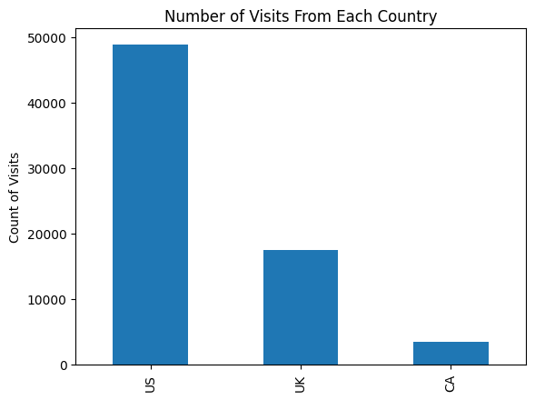

```python
df['country'].value_counts().plot(kind='bar');
plt.title('Number of Visits From Each Country');
plt.ylabel('Count of Visits');
plt.show();
```

`f)` Identification of categorical columns

```python
df.info()

# Converted is not categorical, it is numerical
```

```
<class 'pandas.core.frame.DataFrame'>
RangeIndex: 69889 entries, 0 to 69888
Data columns (total 3 columns):
 #   Column     Non-Null Count  Dtype
---  ------     --------------  -----
 0   country    69889 non-null  object
 1   group      69889 non-null  object
 2   converted  69889 non-null  int64
dtypes: int64(1), object(2)
memory usage: 1.6+ MB
```

`g)` Converted column possible values

```python
df['converted'].unique()
```

```
array([0, 1])
```

The possible values are 0 and 1. This makes sense because its a binary choice whereeither the user converted or they did not (1 converted, 0 did not).

#### Part II - Probability

`a)` What is the probability of an individual converting regardless of the page they receive or the country they are from? Simply, what is the chance of conversion in the dataset?

The probability of overall pooled conversion, as identified earlier, is 0.1305 or approximately 13%.

`b)` Given that an individual was in the `control` group, what is the probability they converted?

```python
x_control = df.query('group == "control"')['converted'].mean()

x_control

# The probability for control conversion is approximately 10.5%.
```

```
0.1052540515600669
```

`c)` Given that an individual was in the `treatment` group, what is the probability they converted?

```python
x_treatment = df.query('group == "treatment"')['converted'].mean()

x_treatment

# The probability for treatmeant conversion is approximately 15.5%.
```

```
0.15532078043793132
```

`d)` Do you see evidence that the treatment is related to higher `converted` rates?

```python
df_delta = x_treatment - x_control

df_delta

# There is initial evidence that delta identifies the treatment group shows a higher observed conversion rate of
# approximately 5 percentage points.
```

```
0.050066728877864425
```

`e)` What is the probability that an individual was in the `treatment`?

```python
df.query('group == "treatment"').shape[0] / df.shape[0]

# The probability that an individual was in the treatment group is approximately 50.4%.
```

```
0.5038131894861853
```

`f)` What is the probability that an individual was from Canada `CA`?

```python
df.query('country == "CA"').shape[0] / df.shape[0]

# The probability that an individual was from Canada is approximately 5%.
```

```
0.04990771079855199
```

`g)` Given that an individual was in the `US`, what was the probability that they `converted`?

$P(\text{converted} == 1|\text{country} ==\text{"US"})$

```python
df.query('country == "US"')['converted'].mean()

# The probability that an individual from the US converted is approximately 13.3%.
```

```
0.13277379733879222
```

`h)` Given that an individual was in the `UK`, what was the probability that they `converted`?

$P(\text{converted} == 1|\text{country} ==\text{"UK"})$

```python
df.query('country == "UK"')['converted'].mean()

# The probability that an individual from the UK converted is approximately 12.5%.
```

```
0.12512107572218106
```

`i)` Do you see evidence that the `converted` rate might differ from one country to the next?

Yes, there is evidence that rates differ as identified above. The US shows approximately .8 percentage points difference above UK conversion rates.

`j)`Table of conversion rates to look at how conversion by country and treatment group vary. Does it appear that there could be an interaction between how country and treatment impact conversion?

```python
# Method 1  - explicitly calculate each probability
print(df.query('country == "US" and group == "control" and converted == 1').shape[0]/df.query('country == "US" and group == "control"').shape[0])
print(df.query('country == "US" and group == "treatment" and converted == 1').shape[0]/df.query('country == "US" and group == "treatment"').shape[0])
```

```
0.10731404958677686
0.1577687626774848
```

```python
# Method 2 - quickly calculate using `groupby`
df.query('country == "US"').groupby('group')['converted'].mean()
```

```
group
control      0.107314
treatment    0.157769
Name: converted, dtype: float64
```

##### Solution -- Complete the Table Here

|  | US | UK | CA |
| --- | --- | --- | --- |
| Control | 10.7% | 10.2% | 9.5% |
| Treatment | 15.8% | 14.9% | 15.4% |

```python
print(df.query('country == "UK" and group == "control" and converted == 1').shape[0]/df.query('country == "UK" and group == "control"').shape[0])
print(df.query('country == "UK" and group == "treatment" and converted == 1').shape[0]/df.query('country == "UK" and group == "treatment"').shape[0])
```

```
0.10164866401364411
0.148698035632709
```

```python
print(df.query('country == "CA" and group == "control" and converted == 1').shape[0]/df.query('country == "CA" and group == "control"').shape[0])
print(df.query('country == "CA" and group == "treatment" and converted == 1').shape[0]/df.query('country == "CA" and group == "treatment"').shape[0])
```

```
0.0944741532976827
0.15401662049861495
```

### Part III - Experimentation

`1.` If you want to assume that the control page is better unless the treatment page proves to be definitely better at a Type I error rate of 5%, you state your null and alternative hypotheses in terms of **$p_{control}$** and **$p_{treatment}$** as:

$H_{0}: p_{control} >= p_{treatment}$

$H_{1}: p_{control} < p_{treatment}$

Which is equivalent to:

$H_{0}: p_{treatment} - p_{control} <= 0$

$H_{1}: p_{treatment} - p_{control} > 0$

Assume under the null hypothesis, $p_{treatment}$ and $p_{control}$ both have "true" success rates equal to the **converted** success rate regardless of page - that is $p_{treatment}$ and $p_{control}$ are equal. Furthermore, assume they are equal to the **converted** rate in `df` regardless of the page.

`a)` The **convert rate** for $p_{treatment}$ under the null. The **convert rate** for $p_{control}$ under the null. The sample size for the `control` and the sample size for the `treatment` are from the original dataset.

```python
p_control_treatment_null  = df['converted'].mean()
n_treatment = df.query('group == "treatment"').shape[0]
n_control = df.query('group == "control"').shape[0]
```

`b)` Use the results from part `a)` to simulate `n_treatment` transactions with a convert rate of `p_treatment_null`.

```python
treatment_converted = np.random.binomial(n=1, p=p_control_treatment_null, size=n_treatment)

treatment_converted
```

```
array([0, 0, 0, ..., 0, 0, 0])
```

`c)` Use the results from part `a)` to simulate `n_control` transactions with a convert rate of `p_control_null`.

```python
control_converted = np.random.binomial(n=1, p=p_control_treatment_null, size=n_control)

control_converted
```

```
array([0, 0, 0, ..., 0, 0, 0])
```

`d)` Find the estimate for $p_{treatment}$ - $p_{control}$ under the null using the simulated values from part `(b)` and `(c)`.

```python
p_treatment = treatment_converted.mean()

p_control = control_converted.mean()

dif_sim = p_treatment - p_control

print(f"Treatment Probability: {p_treatment}")
print(f"Control Probability: {p_control}")
print(f"Difference estimate: {dif_sim}")
```

```
Treatment Probability: 0.13143619891511177
Control Probability: 0.12760251456254687
Difference estimate: 0.003833684352564898
```

`e)` Simulate 500 $p_{treatment}$ - $p_{control}$ values using this same process as `b)`- `d)`. Store all 500 values in an numpy array called **p_diffs**.

```python
p_diffs = []
for _ in range(500):
    treatment_converted_r = np.random.binomial(n=1, p=p_control_treatment_null, size=n_treatment)
    control_converted_r = np.random.binomial(n=1, p=p_control_treatment_null, size=n_control)

    sim_treatment = treatment_converted_r.mean()
    sim_control = control_converted_r.mean()

    p_diff = sim_treatment - sim_control

    p_diffs.append(p_diff)
```

`f)` Plot a histogram of the **p_diffs**.

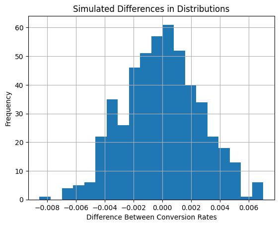

```python
p_diffs = pd.Series(p_diffs)
p_diffs.hist(bins=20)
plt.title("Simulated Differences in Distributions")
plt.ylabel("Frequency")
plt.xlabel("Difference Between Conversion Rates")
```

`g)` What proportion of the **p_diffs** are greater than the difference observed between `treatment` and `control` in `df`?

```python
p_diff_higher = 0

for num in p_diffs:
    if num > 0.050066728877864425:
        p_diff_higher += 1

p_diff_proportion = p_diff_higher / len(p_diffs)

p_diff_proportion
```

```
0.0
```

`h)` In words, explain what was computed in part `g)` What is this value called in scientific studies? What does this value mean in terms of whether or not there is a difference between the new and old pages using our Type I error rate of 0.05?

In part g, we have computed the p-value using the simulated range under the null hypothesis. This value shows the probability that we would get the 5 percentage point value for the treatment difference. For our new and old pages, considering our simulated p-value is basically 0, which is well below the .05 error rate. With this information, I would recommend rejecting the null hypothesis with evidence suggesting the new page is outperforming the old page.

### Part IV - Algorithms

`1.` In this final part, you will see the results acheived in the previous A/B test can also be acheived by performing regression.

`a)` Since each row is either a conversion or no conversion, what type of regression should you be performing in this case?

In this case of only two potential outcomes (i.e. a binary outcome), logistic regression should be performed.

The goal is to use **statsmodels** to fit the regression model you specified in part `a)` to see if there is a significant difference in conversion based on which page a customer receives.

```python
df['intercept'] = 1
df['ab_page'] = pd.get_dummies(df['group'])['treatment']
df.head()
```

|  | country | group | converted | intercept | ab_page |
| --- | --- | --- | --- | --- | --- |
| 0 | UK | control | 0 | 1 | 0 |
| 1 | US | treatment | 1 | 1 | 1 |
| 2 | UK | treatment | 0 | 1 | 1 |
| 3 | UK | control | 0 | 1 | 0 |
| 4 | UK | treatment | 0 | 1 | 1 |

`c)` Create your `X` matrix and `y` response column that will be passed to your model, where you are testing if there is a difference in `treatment` vs. `control`.

```python
X = df[['intercept', 'ab_page']]
y = df['converted']
```

`d)` Use **statsmodels** to import and fit your regression model on the `X` and `y` from part `c)`.

```python
import statsmodels.api as sm

# Logit Model
logit_mod = sm.Logit(y, X)
logit_res = logit_mod.fit()
```

```
Optimization terminated successfully.
         Current function value: 0.384516
         Iterations 6
```

`e)` Provide the summary of the model below.

```python
print(logit_res.summary())
```

```
                           Logit Regression Results
==============================================================================
Dep. Variable:              converted   No. Observations:                69889
Model:                          Logit   Df Residuals:                    69887
Method:                           MLE   Df Model:                            1
Date:                Tue, 02 Sep 2025   Pseudo R-squ.:                0.007175
Time:                        23:06:09   Log-Likelihood:                -26873.
converged:                       True   LL-Null:                       -27068.
Covariance Type:            nonrobust   LLR p-value:                 1.810e-86
==============================================================================
                 coef    std err          z      P>|z|      [0.025      0.975]
------------------------------------------------------------------------------
intercept     -2.1402      0.017   -122.305      0.000      -2.174      -2.106
ab_page        0.4467      0.023     19.539      0.000       0.402       0.492
==============================================================================
```

`f)` What is the p-value associated with **ab_page**? Does it lead to the same conclusion drawn in the **Experiment** section.

The p-value is 0.000 for the ab_page. It results in the same conclusion as the Experimentation. The p-value at 0 is far below the .05 error rate so we would still reject the null hypothesis.

`2. a)` Now create two new columns as dummy variables for `US` and `UK`. Again, use `get_dummies` to add these columns.

```python
### Create the necessary dummy variables
df['intercept'] = 1
df[['US', 'UK']] = pd.get_dummies(df['country'])[['US', 'UK']]
df.head()
```

|  | country | group | converted | intercept | ab_page | US | UK |
| --- | --- | --- | --- | --- | --- | --- | --- |
| 0 | UK | control | 0 | 1 | 0 | 0 | 1 |
| 1 | US | treatment | 1 | 1 | 1 | 1 | 0 |
| 2 | UK | treatment | 0 | 1 | 1 | 0 | 1 |
| 3 | UK | control | 0 | 1 | 0 | 0 | 1 |
| 4 | UK | treatment | 0 | 1 | 1 | 0 | 1 |

```python
X = df[['intercept', 'ab_page', 'US', 'UK']]
y = df['converted']
```

```python
logit_mod_states = sm.Logit(y, X)
logit_res_states = logit_mod_states.fit()
```

```
Optimization terminated successfully.
         Current function value: 0.384463
         Iterations 6
```

```python
print(logit_res_states.summary())
```

```
                           Logit Regression Results
==============================================================================
Dep. Variable:              converted   No. Observations:                69889
Model:                          Logit   Df Residuals:                    69885
Method:                           MLE   Df Model:                            3
Date:                Tue, 02 Sep 2025   Pseudo R-squ.:                0.007312
Time:                        23:06:12   Log-Likelihood:                -26870.
converged:                       True   LL-Null:                       -27068.
Covariance Type:            nonrobust   LLR p-value:                 1.778e-85
==============================================================================
                 coef    std err          z      P>|z|      [0.025      0.975]
------------------------------------------------------------------------------
intercept     -2.1930      0.053    -41.308      0.000      -2.297      -2.089
ab_page        0.4466      0.023     19.534      0.000       0.402       0.491
US             0.0727      0.053      1.372      0.170      -0.031       0.177
UK             0.0067      0.056      0.120      0.905      -0.103       0.117
==============================================================================
```

`e)` What do the `p-values` associated with `US` and `UK` suggest in relation to how they impact `converted`?

The p-values for the US (.170) and UK (.905) suggest that country is insignificant when page assignment is taken into account. The values, especially far above the standard .05 measurement meaning we find no evidence that users in the US and/or UK convert with different rates from those in Canada.